# Path Analysis

ChatGPT 4o

2024-11-20

## 1 起源

路径分析（Path Analysis）是一种用于研究多个变量之间因果关系的统计方法，最早由统计学家和生物学家赖特（Sewall Wright）于20世纪20年代提出。路径分析是结构方程模型（Structural Equation Modeling, SEM）的基础之一，其核心思想是通过有向图和线性回归来表示和检验假设的因果关系。路径分析在社会科学、心理学和医学等领域广泛应用，能够处理多个相互影响的因变量和自变量。

## 2 原理

路径分析的基本原理是通过构建路径图来描述变量之间的关系。路径图中的箭头表示因果方向，而路径系数表示这种因果关系的强度。路径分析通过估计路径系数，来评估模型的拟合效果，并检验变量之间的假设关系。

路径分析通常包括以下几部分：

- **直接效应（Direct Effect）**：自变量对因变量的直接影响，用路径系数表示。
- **间接效应（Indirect Effect）**：通过中介变量传递的影响，表示自变量对因变量的间接作用。
- **总效应（Total Effect）**：直接效应和间接效应之和，表示自变量对因变量的整体影响。

路径系数通常通过多重线性回归模型来估计，并使用相关矩阵和协方差矩阵来描述变量间的关系。

## 3 适用范围

路径分析适用于以下情况：

- **因果模型**：当研究者希望构建和验证多个变量之间的因果关系时，路径分析非常适合。
- **多个因变量和自变量**：路径分析可以处理多个因变量和自变量之间的关系，包括中介效应的检验。
- **数据符合线性回归假设**：路径分析建立在线性回归的基础上，要求数据满足线性关系、正态性等基本假设。

## 4 应用情境

路径分析在多个领域中都有广泛应用，例如：

- **心理学研究**：探讨不同心理因素之间的因果关系，例如压力、焦虑和抑郁之间的相互影响。
- **教育学**：分析学习动机、学习时间和学业成绩之间的因果关系。
- **医学研究**：研究生活方式、健康行为和疾病风险之间的复杂关联。
- **社会学**：分析社会地位、收入和生活满意度之间的关系。

## 5 优缺点

### 优点

- **多变量因果分析**：路径分析能够处理多个变量之间的因果关系，并同时考虑直接和间接效应。
- **可视化因果关系**：通过路径图，可以直观地展示变量之间的因果关系，便于理解和解释。
- **适用于复杂模型**：路径分析可以用于构建和检验较复杂的因果模型，特别是在中介效应和链式效应方面。

### 缺点

- **对模型假设敏感**：路径分析依赖于因果模型的假设，如果模型设定不合理，结果的解释力会大大降低。
- **对数据的要求较高**：路径分析要求数据满足线性关系、正态性和独立性等假设，违背这些假设可能导致错误结论。
- **因果推断的局限性**：路径分析只能检验假设的因果关系，无法证明因果关系的存在，因果推断需要谨慎解释。

## 6 在R中的实现及结果解释

在R中，可以使用`lavaan`包中的`sem()`函数进行路径分析。以下是一个路径分析的实现示例：

```r
# 加载必要的包
library(lavaan)
```

```r
library(ggplot2)

# 示例数据：生成假设数据
set.seed(123)
data <- data.frame(
  X1 = rnorm(100, mean = 5, sd = 2),
  X2 = rnorm(100, mean = 3, sd = 1),
  M = rnorm(100, mean = 4, sd = 1.5),
  Y = rnorm(100, mean = 6, sd = 2)
)

# 定义路径模型
model <- '
  # 路径关系
  M ~ a * X1 + b * X2
  Y ~ c * M + d * X1
'

# 进行路径分析
fit <- sem(model, data = data)

# 输出路径分析结果
summary(fit, fit.measures = TRUE)
```

```
## lavaan 0.6-19 ended normally after 1 iteration
##
##   Estimator                                         ML
##   Optimization method                           NLMINB
##   Number of model parameters                         6
##
##   Number of observations                           100
##
## Model Test User Model:
##
##   Test statistic                                 0.186
##   Degrees of freedom                                 1
##   P-value (Chi-square)                           0.667
##
## Model Test Baseline Model:
##
##   Test statistic                                 2.383
##   Degrees of freedom                                 5
##   P-value                                        0.794
##
## User Model versus Baseline Model:
##
##   Comparative Fit Index (CFI)                    1.000
##   Tucker-Lewis Index (TLI)                      -0.556
##
## Loglikelihood and Information Criteria:
##
##   Loglikelihood user model (H0)               -390.208
##   Loglikelihood unrestricted model (H1)       -390.115
##
##   Akaike (AIC)                                 792.416
##   Bayesian (BIC)                               808.047
##   Sample-size adjusted Bayesian (SABIC)        789.097
##
## Root Mean Square Error of Approximation:
##
##   RMSEA                                          0.000
##   90 Percent confidence interval - lower         0.000
##   90 Percent confidence interval - upper         0.201
##   P-value H_0: RMSEA <= 0.050                    0.704
```

[output cut: 10 more lines]

```
##   Information saturated (h1) model          Structured
##
## Regressions:
##                    Estimate  Std.Err  z-value  P(>|z|)
##   M ~
##     X1         (a)   -0.100    0.077   -1.289    0.197
##     X2         (b)    0.036    0.146    0.244    0.807
##   Y ~
##     M          (c)   -0.075    0.147   -0.511    0.609
##     X1         (d)   -0.058    0.115   -0.504    0.614
##
## Variances:
##                    Estimate  Std.Err  z-value  P(>|z|)
##    .M                 1.975    0.279    7.071    0.000
##    .Y                 4.254    0.602    7.071    0.000
```

### 结果解释

- **路径系数估计**：输出结果中包含路径系数的估计值及其标准误差和显著性检验结果。路径系数表示自变量对因变量的影响强度及方向。
- **拟合度指标**：通过拟合度指标（如CFI、RMSEA等），可以评估模型对数据的拟合效果。如果拟合度指标显示模型拟合较好，则表明假设的因果关系得到一定支持。

### 结果的可视化

路径分析的结果可以通过路径图进行可视化，使变量之间的因果关系更为直观。可以使用`semPlot`包中的`semPaths()`函数来绘制路径图。

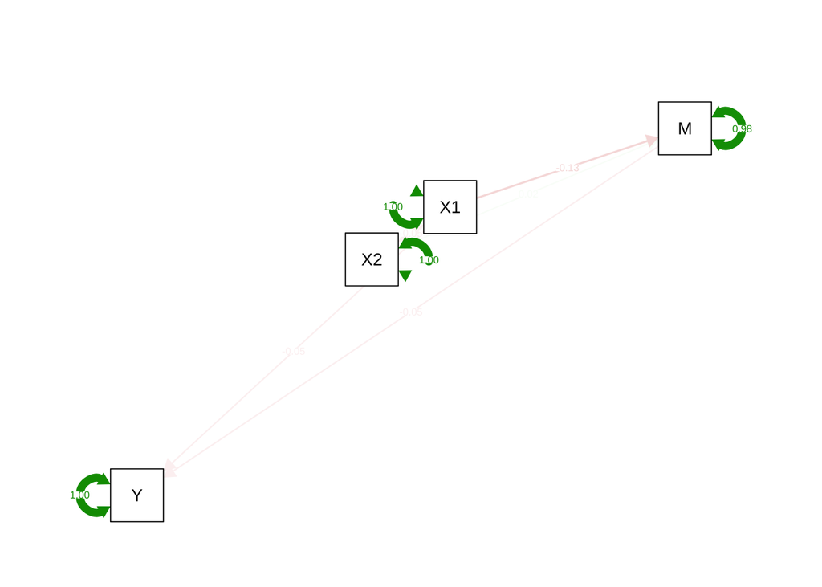

```r
# 安装并加载semPlot包
if (!requireNamespace("semPlot", quietly = TRUE)) {
  install.packages("semPlot")
}
library(semPlot)

# 绘制路径图
semPaths(fit, what = "std", layout = "circle", title = TRUE, nCharNodes = 0, sizeMan = 7, sizeInt = 5)
```

上述代码将生成路径图，展示不同变量之间的因果关系。路径图中的箭头表示因果方向，路径系数标注在箭头上，使得模型的解释更加直观。

## 7 小结

- 路径分析是一种用于研究多个变量之间因果关系的统计方法，能够处理直接和间接效应。
- 适用于因果模型构建和验证，特别是多变量之间的复杂因果关系。
- 具有多变量因果分析、可视化因果关系等优点，但对模型假设和数据要求较高。
- 可以通过R中的`sem()`函数实现路径分析，并结合可视化工具直观展示因果关系。
- 在心理学、教育学、医学和社会学等领域，路径分析是一种重要的工具，用于理解复杂的因果链条和相互影响。